# State-Level Police Union Contributions

Aaron Kessler

June 15, 2020

## Lede/Summary

It’s been a long time coming, but recent weeks have finally brought about a sea change in public opinion toward police in the wake of George Floyd’s death in Minneapolis. Police abuses of power and the targeting, and killing, of black Americans, has sent thousands of people into the streets to protest across the country on a scale not seen in decades. And surveys now show broad support nationwide for reforms to hold police accountable.

But whether this moment translates into the political will strong enough to overcome police departments’ repeated ability to thrwart efforts to change the system remains to be seen. The real test will be in the states themselves, where the police and their powerful unions are major players, having spent tens of millions of dollars to curry favor with state and local politicians.

In fact, police-affiliated unions and associations have contributed **$76,828,078** to state candidates and political parties across the United States since the 2000 election, a new Bloomberg Industry Group analysis found.

The majority of that money has gone to Democrats, who in some places have responded by blocking meaningful change to end excessive use of force, even after horrific incidents. Minnesota’s inaction after the 2016 death of Philando Castile could be exhibit A. Baltimore, where Freddie Gray died in police custody in 2015 as a result of a catastrophic neck injury, similarly failed to subsequently take meaningful action.

Democratic candidates and party committees recieved **$48,019,818** compared with Republicans’ **$27,918,569** over the last two decades, according to the analysis of campaign data compiled by the nonprofit National Institute on Money in Politics.

To be sure, the analysis shows police groups favored the candidates with power - those who are already *incumbents* - more so than a particular party. An overwhelming **72 percent** of police group money to candidates went to incumbents over the last two decades. Another **24 percent** of the money went to contenders for open seats, where there was no current officeholder to run against.  
Only **4 percent** of contributions by police groups went to candidates challenging an incumbent.

## Party Contributions by Election Year/Cycle

Here are what things look like by election cycle going to each party. Note that only a few states have “off-year” elections (on the odd years) which is why those years are always so much lower.

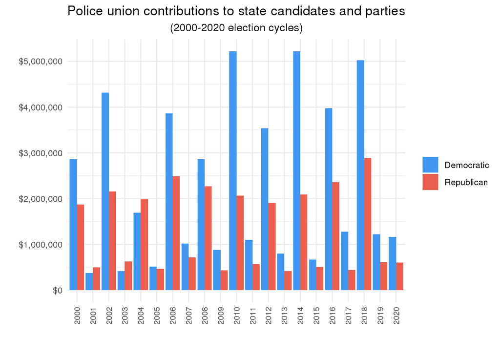

Because **California** has an enormous amount of police group contributions, that state alone makes the Democrats especially dominant in what they receive. The chart below shows the totals **without California** included, which reveals a more nuanced picture of police group activty elsewhere, where the two parties were generally much closer during many cycles. Democrats still loomed much larger in the 2010 and 2014 election years, though things became more neck-and-neck after that.

One potential trend that may be worth exploring is the way these contributions at the state level **mirror in some ways the presidential incumbent** at the time? In that Republican state party candidates and committees generally received a bit more after 9/11 during the W. Bush years, then after Obama was elected there’s a huge surge in Dem money and advantage, then with 2016 and the ascendence of Trump, the Democratic advantage all but disappears and the parties are neck-and-neck again in recent cycles.

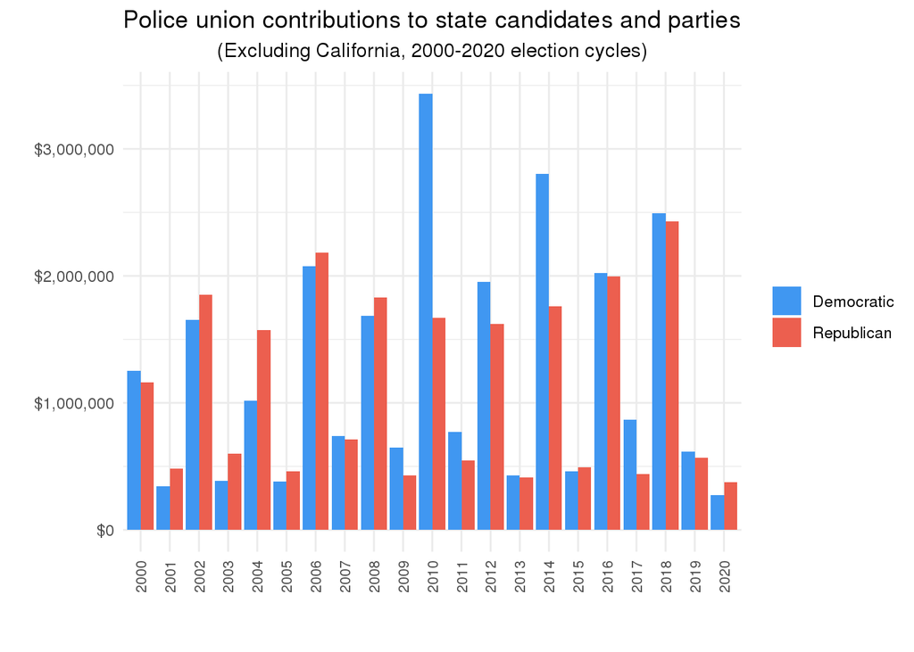

## Top candidates

Who are the candidates who have gotten the biggest bails of cash from police unions and associations over the years? They include both the current Democratic governors of New York, **Andrew Cuomo**, and California, **Gavin Newsom**.

| candidate | election_jurisdiction | total_dollars |
| --- | --- | --- |
| DAVIS, GRAY | CA | 1,126,999.7 |
| CUOMO, ANDREW M | NY | 733,350.0 |
| DINAPOLI, THOMAS P | NY | 615,465.0 |
| BROWN JR, EDMUND G (JERRY) | CA | 499,750.0 |
| ANGELIDES, PHIL | CA | 369,975.0 |
| ABBATE JR, PETER J | NY | 340,353.2 |
| LOCKYER, BILL | CA | 283,099.0 |
| NEWSOM, GAVIN | CA | 259,200.0 |
| SAVINO, DIANE J | NY | 239,875.0 |
| WHITMIRE, JOHN HARRIS | TX | 234,250.0 |

**Cuomo** tops the list of any currently elected state official for contributions from police groups - he’s received a total of **$733,350** (though the arcane nature of New York campaign finance rules means some of that money was given to a joint account he shared with running mates). The longtime state comptroller of New York, **Thomas DiNapoli**, is not far behind with **$615,465**. California’s **Newsom** has taken **$259,200**.

(The champion overall, former California governor Gray Davis, hasn’t been in office since the early 2000s; he was sent packing after an anti-establishment upheaval resulted in a 2003 recall election that scrambled California politics.)

And here are the **top Republican candidates**, all but one of them New York politicans…

| candidate | election_jurisdiction | total_dollars |
| --- | --- | --- |
| SKELOS, DEAN G | NY | 407,550.0 |
| GOLDEN, MARTIN J | NY | 310,450.0 |
| FLANAGAN JR, JOHN J | NY | 203,963.9 |
| FUSCHILLO JR, CHARLES J | NY | 198,681.0 |
| MARCELLINO, CARL L | NY | 196,250.0 |
| ROBACH, JOSEPH E | NY | 175,850.0 |
| LANZA, ANDREW J | NY | 171,425.5 |
| LIBOUS, THOMAS W | NY | 160,168.0 |
| PATAKI, GEORGE E & DONOHUE, MARY O | NY | 159,300.0 |
| DEWHURST III, DAVID H | TX | 136,000.0 |

## Top Donors

The **top police unions and associations** since 2000 in total giving to both parties is perhaps not surprisingly concentrated among groups in California and New York…perhaps not surprising. The states here at the top are huge.

| contributor | total_dollars |
| --- | --- |
| PEACE OFFICERS RESEARCH ASSOCIATION OF CALIFORNIA | 6,837,719 |
| CALIFORNIA ASSOCIATION OF HIGHWAY PATROLMEN | 5,438,760 |
| FLORIDA POLICE BENEVOLENT ASSOCIATION | 5,062,288 |
| CALIFORNIA STATEWIDE LAW ENFORCEMENT ASSOCIATION | 3,892,552 |
| NEW YORK STATE TROOPERS PBA | 3,337,931 |
| CALIFORNIA UNION OF SAFETY EMPLOYEES | 2,297,840 |
| NEW JERSEY STATE PBA LOCAL 600 | 1,980,387 |
| PENNSYLVANIA STATE TROOPERS ASSOCIATION | 1,927,654 |
| POLICE BENEVOLENT ASSOCIATION OF THE CITY OF NEW YORK | 1,813,156 |
| NASSAU COUNTY POLICE BENEVOLENT ASSOCIATION | 1,477,280 |

The top donor, the *Peace Officers Research Assn of California*, does indeed give to a variety of candidates and is a big-dollar donor to the CA Democratic Party. Not just ballot initatives as had been suspected.

| recipient | recipient_type | party | total_dollars |
| --- | --- | --- | --- |
| CALIFORNIA DEMOCRATIC PARTY | party committee | Democratic | 1,693,900.0 |
| DAVIS, GRAY | candidate | Democratic | 180,169.5 |
| BROWN JR, EDMUND G (JERRY) | candidate | Democratic | 93,300.0 |
| ANGELIDES, PHIL | candidate | Democratic | 79,475.0 |
| BUSTAMANTE, CRUZ M | candidate | Democratic | 70,600.0 |
| PADILLA, ALEX | candidate | Democratic | 62,300.0 |
| CHIANG, JOHN | candidate | Democratic | 62,100.0 |
| NEWSOM, GAVIN | candidate | Democratic | 59,400.0 |
| MA, FIONA | candidate | Democratic | 56,150.0 |
| SHELLEY, KEVIN | candidate | Democratic | 52,100.0 |

## Where the money dominates

But if we look at **state-by-state giving accounting for the populations**, we find something interesting.

Firstly, it turns out **California** and **New York** still top the list even after adjusting for their populations.

| election_jurisdiction | total_dollars | population | dollars_per1000ppl | rank_dollars_per1000ppl | rank_population |
| --- | --- | --- | --- | --- | --- |
| NY | $14,923,644 | 19,618,453 | $760.69 | 1 | 4 |
| CA | $26,431,159 | 39,148,760 | $675.15 | 2 | 1 |
| AK | $412,362 | 738,516 | $558.37 | 3 | 47 |
| NJ | $4,339,351 | 8,881,845 | $488.56 | 4 | 11 |
| FL | $6,278,759 | 20,598,139 | $304.82 | 5 | 3 |
| RI | $317,855 | 1,056,611 | $300.82 | 6 | 43 |
| NV | $832,020 | 2,922,849 | $284.66 | 7 | 34 |
| WA | $2,025,249 | 7,294,336 | $277.65 | 8 | 13 |
| DE | $238,219 | 949,495 | $250.89 | 9 | 45 |
| VA | $2,101,777 | 8,413,774 | $249.80 | 10 | 12 |

#### Here are the rankings for **just candidates alone**…

| election_jurisdiction | total_dollars | population | dollars_per1000ppl | rank_dollars_per1000ppl | rank_population |
| --- | --- | --- | --- | --- | --- |
| AK | $412,112 | 738,516 | $558.03 | 1 | 47 |
| NY | $10,586,764 | 19,618,453 | $539.63 | 2 | 4 |
| CA | $20,174,622 | 39,148,760 | $515.33 | 3 | 1 |
| NJ | $3,024,581 | 8,881,845 | $340.54 | 4 | 11 |
| RI | $301,830 | 1,056,611 | $285.66 | 5 | 43 |
| WA | $1,743,449 | 7,294,336 | $239.01 | 6 | 13 |
| DE | $221,194 | 949,495 | $232.96 | 7 | 45 |
| VA | $1,641,725 | 8,413,774 | $195.12 | 8 | 12 |
| NV | $568,770 | 2,922,849 | $194.59 | 9 | 34 |
| MA | $1,314,898 | 6,830,193 | $192.51 | 10 | 15 |

#### And here are the rankings for **just political party committees alone** (note Minnesota’s prominence here)…

| election_jurisdiction | total_dollars | population | dollars_per1000ppl | rank_dollars_per1000ppl | rank_population |
| --- | --- | --- | --- | --- | --- |
| NY | $4,336,880 | 19,618,453 | $221.06 | 1 | 4 |
| FL | $3,663,290 | 20,598,139 | $177.85 | 2 | 3 |
| CA | $6,256,537 | 39,148,760 | $159.81 | 3 | 1 |
| NJ | $1,314,770 | 8,881,845 | $148.03 | 4 | 10 |
| NV | $263,250 | 2,922,849 | $90.07 | 5 | 30 |
| MN | $467,950 | 5,527,358 | $84.66 | 6 | 21 |
| VA | $460,052 | 8,413,774 | $54.68 | 7 | 11 |
| MI | $479,750 | 9,957,488 | $48.18 | 8 | 9 |
| WA | $281,800 | 7,294,336 | $38.63 | 9 | 12 |
| WI | $193,691 | 5,778,394 | $33.52 | 10 | 19 |